# Dementia Prevention

## Morgan Zimmerman

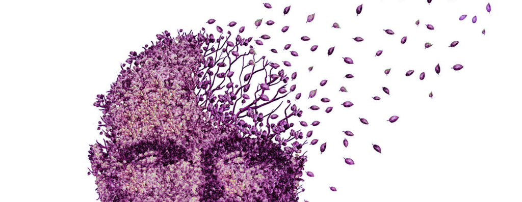

## Problem -

- Research on dementia prevalence and potentially related risk factors is $\color{red}{\text{scarce}}$
- There are $\color{red}{\text{no}}$ disease-modifying agents for dementia
- Prevention and intervention measures for $\color{red}{\text{high-risk}}$ populations is desired

## Background -

- Evidence of $\color{red}{\text{decline}}$ in the prevalence of dementia in high-income countries
- Lifestyle activities that optimize use of cognitive strategies and healthy dietary patterns might help $\color{red}{\text{preserve}}$ cognition

## Data -

- Public NIH dataset
- Focused on 686 individuals in Indonesia (486 without dementia, 200 with dementia)
- Includes demographics, biomarkers, and lifestyle factors (i.e., activity, diet)

```python
dta.head(10)
```

|  | Participant_ID | Category | Age_yrs | Age_category | Education_yrs | Education_category | Sex | Marital_status | Income | Occupation_class | ... | Vegetable | Vegetable_category | Fruit | Fruit_category | Salted_fish | Salted_fish_category | Instant_noodle | Instant_noodle_category | Tempe | Tempe_category |
| --- | --- | --- | --- | --- | --- | --- | --- | --- | --- | --- | --- | --- | --- | --- | --- | --- | --- | --- | --- | --- | --- |
| 0 | 80001 | Dementia | 70.0 | 60-74 | 3.0 | 0-6 years | Female | Married | No Income | housewife | ... | 2 times/day | Frequent | Sometimes | Non Frequent | Sometimes | Non-Frequent | Sometimes | Non-Frequent | Few times/week | Non-Frequent |
| 1 | 80002 | Normal | 63.0 | 60-74 | 0.0 | 0-6 years | Female | Single | < monthly minimum wage | profesional | ... | 3-4 times/week | Non Frequent | Sometimes | Non Frequent | Sometimes | Non-Frequent | Sometimes | Non-Frequent | Few times/week | Non-Frequent |
| 2 | 80003 | Normal | 64.0 | 60-74 | 6.0 | 0-6 years | Female | Married | No Income | housewife | ... | 3-4 times/week | Non Frequent | Sometimes | Non Frequent | Sometimes | Non-Frequent | NaN | NaN | NaN | NaN |
| 3 | 80004 | Normal | 62.0 | 60-74 | 6.0 | 0-6 years | Female | Married | ≥ monthly minimum wage | housewife | ... | 2 times/day | Frequent | Sometimes | Non Frequent | Sometimes | Non-Frequent | Few times/week | Frequent | Few times/week | Non-Frequent |
| 4 | 80005 | Dementia | 78.0 | >75 | 3.0 | 0-6 years | Female | Married | No Income | housewife | ... | 2 times/day | Frequent | Sometimes | Non Frequent | Sometimes | Non-Frequent | Sometimes | Non-Frequent | Sometimes | Non-Frequent |
| 5 | 80006 | Dementia | 78.0 | >75 | 0.0 | 0-6 years | Female | Married | No Income | housewife | ... | 3-4 times/week | Non Frequent | 1 time/day | Frequent | Few times/week | Frequent | Every Meal | Frequent | Few times/week | Non-Frequent |
| 6 | 80007 | Normal | 75.0 | >75 | 6.0 | 0-6 years | Female | Single | No Income | housewife | ... | 3-4 times/week | Non Frequent | 3-4 times/week | Non Frequent | Sometimes | Non-Frequent | Sometimes | Non-Frequent | Few times/week | Non-Frequent |
| 7 | 80009 | Normal | 64.0 | 60-74 | 4.0 | 0-6 years | Female | Married | No Income | housewife | ... | 3-4 times/week | Non Frequent | Sometimes | Non Frequent | Sometimes | Non-Frequent | NaN | NaN | NaN | NaN |
| 8 | 80010 | Dementia | 66.0 | 60-74 | 2.0 | 0-6 years | Female | Single | No Income | notworking | ... | 3-4 times/week | Non Frequent | 3-4 times/week | Non Frequent | Sometimes | Non-Frequent | NaN | NaN | NaN | NaN |
| 9 | 80011 | Dementia | 73.0 | 60-74 | 0.0 | 0-6 years | Female | Single | No Income | housewife | ... | 3-4 times/week | Non Frequent | Sometimes | Non Frequent | Sometimes | Non-Frequent | Few times/week | Frequent | Few times/week | Non-Frequent |

10 rows × 78 columns

## Considered Methods -

- $\color{red}{\text{Data Wrangling}}$
  - *Clean data*
  - *Rename variables*
  - *Convert data types*
  - *Handle categorical variables*
  - *Produce subset dataframes*
- $\color{red}{\text{Data Exploration}}$
  - *Ask questions of data*
  - *Plot distributions, other visualizations*
  - *Detect missingness, outliers*
  - *Calculate preliminary statistics*
- $\color{red}{\text{Machine Learning}}$
  - *Sampling*
  - *Split train/test data*
  - *Run models*
  - *Calculate predictive accuracies*

```python
## Methods Used - Data Wrangling
# Import the Excel sheet
dta_messy = pd.read_excel('data/Data_Sheet_1.xlsx',
                   header=[0])
print('Methods Used - Data Wrangling')
# Preview the first ten rows Excel sheet
dta_messy.head(5)
```

```
Methods Used - Data Wrangling
```

|  | No. | Participant | Category | Age | Unnamed: 4 | Education | Unnamed: 6 | Sex | Marital Status | Income | ... | Unnamed: 69 | Unnamed: 70 | Unnamed: 71 | Unnamed: 72 | Unnamed: 73 | Unnamed: 74 | Unnamed: 75 | Unnamed: 76 | Unnamed: 77 | Unnamed: 78 |
| --- | --- | --- | --- | --- | --- | --- | --- | --- | --- | --- | --- | --- | --- | --- | --- | --- | --- | --- | --- | --- | --- |
| 0 | NaN | NaN | NaN | Years | Category | Years | Category | NaN | NaN | NaN | ... | Vegetable | Vege Category | Fruit | Fruit Category | Salted Fish | Salted Fish Category | Instant Noodle | Int.Noodle Category | Tempe | Tempe Category |
| 1 | 1.0 | 80001.0 | Dementia | 70 | 60-74 | 3 | 0-6 years | Female | Married | No Income | ... | 2 times/day | Frequent | Sometimes | Non Frequent | Sometimes | Non-Frequent | Sometimes | Non-Frequent | Few times/week | Non-Frequent |
| 2 | 2.0 | 80002.0 | Normal | 63 | 60-74 | 0 | 0-6 years | Female | Single | < monthly minimum wage | ... | 3-4 times/week | Non Frequent | Sometimes | Non Frequent | Sometimes | Non-Frequent | Sometimes | Non-Frequent | Few times/week | Non-Frequent |
| 3 | 3.0 | 80003.0 | Normal | 64 | 60-74 | 6 | 0-6 years | Female | Married | No Income | ... | 3-4 times/week | Non Frequent | Sometimes | Non Frequent | Sometimes | Non-Frequent | NaN | NaN | NaN | NaN |
| 4 | 4.0 | 80004.0 | Normal | 62 | 60-74 | 6 | 0-6 years | Female | Married | ≥ monthly minimum wage | ... | 2 times/day | Frequent | Sometimes | Non Frequent | Sometimes | Non-Frequent | Few times/week | Frequent | Few times/week | Non-Frequent |

5 rows × 79 columns

```python
print('Dealing with categorical variables -')
dta_dummy.head(5)
```

```
Dealing with categorical variables -
```

|  | Participant_ID | Age_yrs | Education_yrs | BP_sistol | BP_diastol | BMI | GDS | Glucose | Triglyceride | HDL | ... | Vegetable_category_Frequent | Vegetable_category_Non Frequent | Fruit_category_Frequent | Fruit_category_Non Frequent | Salted_fish_category_Frequent | Salted_fish_category_Non-Frequent | Instant_noodle_category_Frequent | Instant_noodle_category_Non-Frequent | Tempe_category_Frequent | Tempe_category_Non-Frequent |
| --- | --- | --- | --- | --- | --- | --- | --- | --- | --- | --- | --- | --- | --- | --- | --- | --- | --- | --- | --- | --- | --- |
| 0 | 80001 | 70.0 | 3.0 | 150.0 | 60.0 | 19.95 | 3.0 | 81.0 | 90.0 | 67.0 | ... | 1 | 0 | 0 | 1 | 0 | 1 | 0 | 1 | 0 | 1 |
| 1 | 80002 | 63.0 | 0.0 | 140.0 | 90.0 | 22.04 | 1.0 | 82.0 | 61.0 | 70.0 | ... | 0 | 1 | 0 | 1 | 0 | 1 | 0 | 1 | 0 | 1 |
| 2 | 80003 | 64.0 | 6.0 | 150.0 | 100.0 | 22.02 | 0.0 | NaN | NaN | NaN | ... | 0 | 1 | 0 | 1 | 0 | 1 | 0 | 0 | 0 | 0 |
| 3 | 80004 | 62.0 | 6.0 | 120.0 | 80.0 | 28.77 | 0.0 | 86.0 | 183.0 | 42.0 | ... | 1 | 0 | 0 | 1 | 0 | 1 | 1 | 0 | 0 | 1 |
| 4 | 80005 | 78.0 | 3.0 | 210.0 | 100.0 | 24.79 | 6.0 | 95.0 | 229.0 | 60.0 | ... | 1 | 0 | 0 | 1 | 0 | 1 | 0 | 1 | 0 | 1 |

5 rows × 111 columns

```
Methods Used - Data Exploration
```

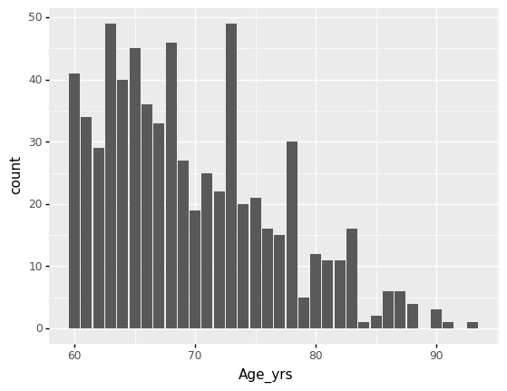

```python
## Methods Used - Data Exploration
print('Methods Used - Data Exploration')
(ggplot(dta,aes(x='Age_yrs')) +
  geom_bar())
```

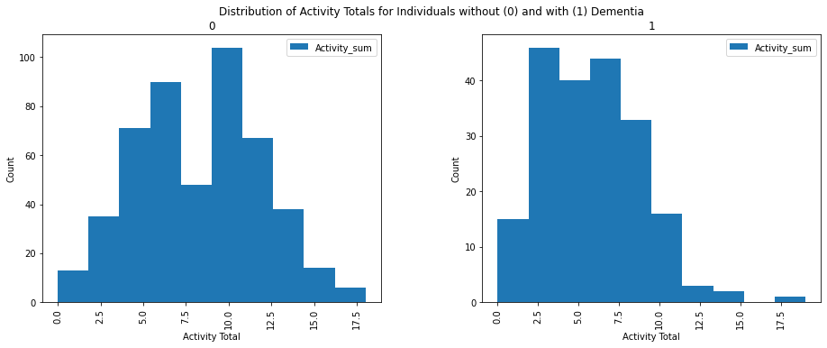

```python
dta_active['Activity_sum']= dta_active.iloc[:, -31:-1].sum(axis=1)
dta_act = dta_active.hist(column='Activity_sum',
                               by='Dementia',
                               figsize=(15, 5.5),
                               legend=True)
for total in dta_act.flatten():
    total.set_xlabel("Activity Total")
    total.set_ylabel("Count")
pl.suptitle('Distribution of Activity Totals for Individuals without (0) and with (1) Dementia')
```

```
PRELIMINARY RESULTS - Age, AMT Scores
```

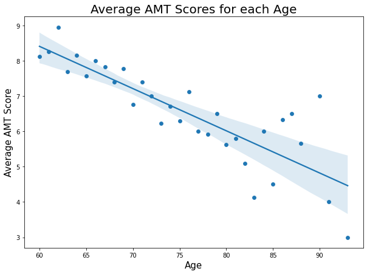

```python
print('PRELIMINARY RESULTS - Age, AMT Scores')
age_avgscore = dta.groupby('Age_yrs', as_index=False)['AMT'].mean()
age_amt = age_avgscore.plot.scatter(x='Age_yrs',
                      y='AMT',
                      figsize=(10, 7))
sns.regplot('Age_yrs', 'AMT', data = age_avgscore)
plt.title('Average AMT Scores for each Age', fontsize=20)
plt.xlabel('Age', fontsize=15)
plt.ylabel('Average AMT Score', fontsize=15)
```

```python
print("'sklearn' Linear Regression Model")
print('\n')

# model on averages
x=age_avgscore['Age_yrs'].to_numpy().reshape((-1, 1))
y=age_avgscore['AMT'].to_numpy()
model1 = LinearRegression()
model1.fit(x, y)
r_sq1 = model1.score(x, y)
print('R-squared:', r_sq1)
print('Intercept Estimate:', model1.intercept_)
print('Slope:', model1.coef_)
print('\n')
```

```
'sklearn' Linear Regression Model


R-squared: 0.7011642281300936
Intercept Estimate: 15.603663867477344
Slope: [-0.11978442]
```

```
Methods Used - Machine Learning
```

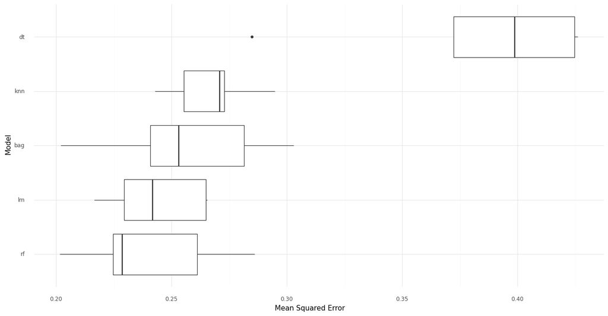

```python
print('Methods Used - Machine Learning')

dta1 = dta_active.dropna()
sample = dta1.groupby("Dementia").sample(n=190, random_state=1988)
sample.columns

y = sample['Dementia']
X = sample[['Reads', 'Surfs_Internet', 'Plays_Games', 'Invests', 'Discusses',
                    'Writes_Paints', 'Plays_Instrument', 'Intellect_Other',
                    'Attends_Class', 'Joins_Center', 'Volunteers', 'Watches_Entertainment',
                    'Meets_People', 'Sees_Dramas', 'Sings', 'Attends_Religion', 'Social_Other',
                    'Watches_TV', 'Listens_Music', 'Shops', 'Cooks', 'Fishes', 'Has_Pets',
                    'Gets_Massages', 'Recreation_Other', 'Does_Yoga', 'Strenuous_Aerobic',
                    'Light_Aerobic', 'Strenuous_Aerobic', 'Stretches_Tones', 'Physical_Other']]

train_X, test_X, train_y, test_y = train_test_split(X,y,test_size=.25,random_state=1988)

scaler = pp.MinMaxScaler()
col_names = list(train_X)
train_X = scaler.fit_transform(train_X)
train_X = pd.DataFrame(train_X,columns=col_names)

fold_generator = KFold(n_splits=5, shuffle=True,random_state=111)
use_metrics = ["neg_mean_squared_error"]

lm_scores = cross_validate(LM(),train_X,train_y, cv = fold_generator, scoring =use_metrics)
knn_scores = cross_validate(KNN(),train_X,train_y, cv = fold_generator, scoring =use_metrics)
dt_scores = cross_validate(DTree(),train_X,train_y, cv = fold_generator, scoring =use_metrics)
bag_scores = cross_validate(Bag(),train_X,train_y, cv = fold_generator, scoring =use_metrics)
rf_scores = cross_validate(RF(),train_X,train_y, cv = fold_generator, scoring =use_metrics)

# Collect all the metrics we care about as a dictionary
collect_scores = \
dict(lm = lm_scores['test_neg_mean_squared_error']*-1,
     knn = knn_scores['test_neg_mean_squared_error']*-1,
     dt = dt_scores['test_neg_mean_squared_error']*-1,
     bag = bag_scores['test_neg_mean_squared_error']*-1,
     rf = rf_scores['test_neg_mean_squared_error']*-1)

# Convert to a data frame and reshape
collect_scores = pd.DataFrame(collect_scores).melt(var_name="Model",value_name="MSE")
collect_scores

# Get the order of the models
order = (collect_scores.groupby('Model').mean().sort_values(by="MSE").index.tolist())

# Plot
(
    ggplot(collect_scores,
          aes(x="Model",y="MSE")) +
    geom_boxplot() +
    scale_x_discrete(limits=order) +
    labs(x="Model",y="Mean Squared Error") +
    coord_flip() +
    theme_minimal() +
    theme(figure_size=(16, 8))
)
```

## Lessons Learned -

- Modeling and intrepration on a dataset that is primarily $\color{red}{\text{categorical}}$
- $\color{red}{\text{"Bad"}}$ predictive accuracy is also informative
- Where I'm going from here